# Python Project - 03 - Graded Project (GLCA- DA- CHN- NOV-23)-Madhumitha.E

# Exploratory Data Analysis on YouTube data.

YouTube Dislikes Dataset: ● This dataset contains information about trending YouTube videos from August 2020 to December 2021 for the USA, Canada, and Great Britain. ● This dataset contains the latest possible information about dislikes,likes,views and more which was collected just before December 13. The information was collected by videos that had been trending in the USA, Canada, and Great Britain for a year prior. Attribute Information: SL.No Column Name Description Video ID Unique video id. Title Video title. Channel ID Id of the channel. Channel Title Title of the channel. Published at Video publication date. View count Number of views. Likes Number of likes. Dislikes Number of dislikes. Comment Count Number of comments. Tags Tags (in one string). Description Video description. Comments 20 Video comments (in one string)

# 1) Import required libraries and read the provided dataset (youtube_dislike_dataset.csv) and retrieve top 5 and bottom 5 records.

```python
# Importing libraries
import pandas as pd
import numpy as np
```

```python
# reading the dataset
df=pd.read_csv("youtube_dislike_dataset (1).csv")
df
```

|  | video_id | title | channel_id | channel_title | published_at | view_count | likes | dislikes | comment_count | tags | description | comments |
| --- | --- | --- | --- | --- | --- | --- | --- | --- | --- | --- | --- | --- |
| 0 | --0bCF-iK2E | Jadon Sancho Magical Skills & Goals | UC6UL29enLNe4mqwTfAyeNuw | Bundesliga | 2021-07-01 10:00:00 | 1048888 | 19515 | 226 | 1319 | football soccer ftbol alemn Bundesliga season ... | Enjoy the best skills and goals from Jadon San... | Respect to Dortmund fans,must be sad losing hi... |
| 1 | --14w5SOEUs | Migos - Avalanche (Official Video) | UCGIelM2Dj3zza3xyV3pL3WQ | MigosVEVO | 2021-06-10 16:00:00 | 15352638 | 359277 | 7479 | 18729 | Migos Avalanche Quality Control Music/Motown R... | Watch the the official video for Migos - "Aval... | Migos just makes me want to live my live to th... |
| 2 | --40TEbZ9Is | Supporting Actress in a Comedy: 73rd Emmys | UClBKH8yZRcM4AsRjDVEdjMg | Television Academy | 2021-09-20 01:03:32 | 925281 | 11212 | 401 | 831 |  | Hannah Waddingham wins the Emmy for Supporting... | Hannah's energy bursts through any screen. Wel... |
| 3 | --4tfbSyYDE | JO1'YOUNG (JO1 ver.)' PERFORMANCE VIDEO | UCsmXiDP8S40uBeJYxvyulmA | JO1 | 2021-03-03 10:00:17 | 2641597 | 39131 | 441 | 3745 | PRODUCE101JAPAN JO1 TheSTAR STA... | JO1'YOUNG (JO1 ver.)' PERFORMANCE VIDEO\n\n---... | youngVer>< REN is really PERFECT. It's not ju... |
| 4 | --DKkzWVh-E | Why Retaining Walls Collapse | UCMOqf8ab-42UUQIdVoKwjlQ | Practical Engineering | 2021-12-07 13:00:00 | 715724 | 32887 | 367 | 1067 | retaining wall New Jersey highway Direct Conne... | One of the most important (and innocuous) part... | Keep up with all my projects here: https://pr... |
| ... | ... | ... | ... | ... | ... | ... | ... | ... | ... | ... | ... | ... |
| 37417 | zzd4ydafGR0 | Lil Tjay - Calling My Phone (feat. 6LACK) [Off... | UCEB4a5o_6KfjxHwNMnmj54Q | Lil Tjay | 2021-02-12 05:03:49 | 120408275 | 2180780 | 35871 | 81360 | Lil Tjay Steady Calling My Phone Calling My Ph... | Official video for "Calling My Phone" by Lil T... | 'DESTINED 2 WIN' OUT NOW !! https://liltjay.ln... |
| 37418 | zziBybeSAtw | PELICANS at LAKERS \| FULL GAME HIGHLIGHTS \| Ja... | UCWJ2lWNubArHWmf3FIHbfcQ | NBA | 2021-01-16 05:39:05 | 2841917 | 20759 | 1049 | 2624 | NBA G League Basketball game-0022000187 Lakers... | PELICANS at LAKERS \| FULL GAME HIGHLIGHTS \| Ja... | Montrezl Harrell is going crazy with the rebou... |
| 37419 | zzk09ESX7e0 | [MV] (MAMAMOO) - Where Are We Now | UCuhAUMLzJxlP1W7mEk0_6lA | MAMAMOO | 2021-06-02 09:00:10 | 13346678 | 720854 | 4426 | 90616 | MAMAMOO WAW WAW MAMAMOO WAW Where Are We Now... | [MV] (MAMAMOO) - Where Are We Now\n\nInstagra... | I honestly do not know why this song hit so ha... |
| 37420 | zzmQEb0Em5I | FELLIPE ESCUDERO- Master Podcast #12 | UC8NjnNWMsRqq11NYvHAQb1g | Master Podcast | 2020-10-20 20:59:30 | 252057 | 19198 | 1234 | 1471 | master masterpodcast lord lord vinheteiro z z ... | DOCTOR HAIR\nhttps://www.thedoctorhair.com/?fb... | Foi um prazer passar esta tarde com vocs debat... |
| 37421 | zzxPZwaA-8w | Gareth Bale brace secures dramatic comeback on... | UCEg25rdRZXg32iwai6N6l0w | Tottenham Hotspur | 2021-05-23 21:00:31 | 2252090 | 34063 | 868 | 2004 | Spurs Tottenham Hotspur Tottenham Leicester ... | Two minute highlights from Tottenham Hotspur's... | Thank you Kane for everything you have given t... |

37422 rows × 12 columns

```python
# printing the first 5 rows (head)
df.head(5)
```

|  | video_id | title | channel_id | channel_title | published_at | view_count | likes | dislikes | comment_count | tags | description | comments |
| --- | --- | --- | --- | --- | --- | --- | --- | --- | --- | --- | --- | --- |
| 0 | --0bCF-iK2E | Jadon Sancho Magical Skills & Goals | UC6UL29enLNe4mqwTfAyeNuw | Bundesliga | 2021-07-01 10:00:00 | 1048888 | 19515 | 226 | 1319 | football soccer ftbol alemn Bundesliga season ... | Enjoy the best skills and goals from Jadon San... | Respect to Dortmund fans,must be sad losing hi... |
| 1 | --14w5SOEUs | Migos - Avalanche (Official Video) | UCGIelM2Dj3zza3xyV3pL3WQ | MigosVEVO | 2021-06-10 16:00:00 | 15352638 | 359277 | 7479 | 18729 | Migos Avalanche Quality Control Music/Motown R... | Watch the the official video for Migos - "Aval... | Migos just makes me want to live my live to th... |
| 2 | --40TEbZ9Is | Supporting Actress in a Comedy: 73rd Emmys | UClBKH8yZRcM4AsRjDVEdjMg | Television Academy | 2021-09-20 01:03:32 | 925281 | 11212 | 401 | 831 |  | Hannah Waddingham wins the Emmy for Supporting... | Hannah's energy bursts through any screen. Wel... |
| 3 | --4tfbSyYDE | JO1'YOUNG (JO1 ver.)' PERFORMANCE VIDEO | UCsmXiDP8S40uBeJYxvyulmA | JO1 | 2021-03-03 10:00:17 | 2641597 | 39131 | 441 | 3745 | PRODUCE101JAPAN JO1 TheSTAR STA... | JO1'YOUNG (JO1 ver.)' PERFORMANCE VIDEO\n\n---... | youngVer>< REN is really PERFECT. It's not ju... |
| 4 | --DKkzWVh-E | Why Retaining Walls Collapse | UCMOqf8ab-42UUQIdVoKwjlQ | Practical Engineering | 2021-12-07 13:00:00 | 715724 | 32887 | 367 | 1067 | retaining wall New Jersey highway Direct Conne... | One of the most important (and innocuous) part... | Keep up with all my projects here: https://pr... |

```python
# printing the last 5 rows (tail)
df.tail(5)
```

|  | video_id | title | channel_id | channel_title | published_at | view_count | likes | dislikes | comment_count | tags | description | comments |
| --- | --- | --- | --- | --- | --- | --- | --- | --- | --- | --- | --- | --- |
| 37417 | zzd4ydafGR0 | Lil Tjay - Calling My Phone (feat. 6LACK) [Off... | UCEB4a5o_6KfjxHwNMnmj54Q | Lil Tjay | 2021-02-12 05:03:49 | 120408275 | 2180780 | 35871 | 81360 | Lil Tjay Steady Calling My Phone Calling My Ph... | Official video for "Calling My Phone" by Lil T... | 'DESTINED 2 WIN' OUT NOW !! https://liltjay.ln... |
| 37418 | zziBybeSAtw | PELICANS at LAKERS \| FULL GAME HIGHLIGHTS \| Ja... | UCWJ2lWNubArHWmf3FIHbfcQ | NBA | 2021-01-16 05:39:05 | 2841917 | 20759 | 1049 | 2624 | NBA G League Basketball game-0022000187 Lakers... | PELICANS at LAKERS \| FULL GAME HIGHLIGHTS \| Ja... | Montrezl Harrell is going crazy with the rebou... |
| 37419 | zzk09ESX7e0 | [MV] (MAMAMOO) - Where Are We Now | UCuhAUMLzJxlP1W7mEk0_6lA | MAMAMOO | 2021-06-02 09:00:10 | 13346678 | 720854 | 4426 | 90616 | MAMAMOO WAW WAW MAMAMOO WAW Where Are We Now... | [MV] (MAMAMOO) - Where Are We Now\n\nInstagra... | I honestly do not know why this song hit so ha... |
| 37420 | zzmQEb0Em5I | FELLIPE ESCUDERO- Master Podcast #12 | UC8NjnNWMsRqq11NYvHAQb1g | Master Podcast | 2020-10-20 20:59:30 | 252057 | 19198 | 1234 | 1471 | master masterpodcast lord lord vinheteiro z z ... | DOCTOR HAIR\nhttps://www.thedoctorhair.com/?fb... | Foi um prazer passar esta tarde com vocs debat... |
| 37421 | zzxPZwaA-8w | Gareth Bale brace secures dramatic comeback on... | UCEg25rdRZXg32iwai6N6l0w | Tottenham Hotspur | 2021-05-23 21:00:31 | 2252090 | 34063 | 868 | 2004 | Spurs Tottenham Hotspur Tottenham Leicester ... | Two minute highlights from Tottenham Hotspur's... | Thank you Kane for everything you have given t... |

# 2) Check the info of the dataframe and write your inferences on data types and shape of the dataset.

```python
# information of the dataset
df.info()
```

```
<class 'pandas.core.frame.DataFrame'>
RangeIndex: 37422 entries, 0 to 37421
Data columns (total 12 columns):
 #   Column         Non-Null Count  Dtype
---  ------         --------------  -----
 0   video_id       37422 non-null  object
 1   title          37422 non-null  object
 2   channel_id     37422 non-null  object
 3   channel_title  37422 non-null  object
 4   published_at   37422 non-null  object
 5   view_count     37422 non-null  int64
 6   likes          37422 non-null  int64
 7   dislikes       37422 non-null  int64
 8   comment_count  37422 non-null  int64
 9   tags           37422 non-null  object
 10  description    37422 non-null  object
 11  comments       37264 non-null  object
dtypes: int64(4), object(8)
memory usage: 3.4+ MB
```

```python
df.shape
```

```
(37422, 12)
```

Inference: This is a Pandas DataFrame with 37,422 entries and 12 columns. Each row represents information about a video. There are 12 columns and 37422 rows in this YouTube dataset. There are 4 integer columns such as ["view_count","likes","dislikes","comment_count"] and 8 object columns ["video_id","title","channel_id","channel_title","published_at","tags","description","comments"] The dtypes consist of int64(4), object(8). With the memory usage of 3.4+MB

# 3) Check for the Percentage of the missing values and drop or impute them.

```python
# checking for missing values
#df.isnull().sum() # get the number of missing values for each columns
df.isnull().sum()/df.shape[0]*100  # getting the percentage of missing value
```

```
video_id         0.000000
title            0.000000
channel_id       0.000000
channel_title    0.000000
published_at     0.000000
view_count       0.000000
likes            0.000000
dislikes         0.000000
comment_count    0.000000
tags             0.000000
description      0.000000
comments         0.422212
dtype: float64
```

```python
# dropping the comment column because it has 0.40 % of missing values, even imputing the comments columm it won't make much difference
df.drop(["comments"],inplace=True, axis=1)
# checking if the comment column has dropped
df.head(3)
```

|  | video_id | title | channel_id | channel_title | published_at | view_count | likes | dislikes | comment_count | tags | description |
| --- | --- | --- | --- | --- | --- | --- | --- | --- | --- | --- | --- |
| 0 | --0bCF-iK2E | Jadon Sancho Magical Skills & Goals | UC6UL29enLNe4mqwTfAyeNuw | Bundesliga | 2021-07-01 10:00:00 | 1048888 | 19515 | 226 | 1319 | football soccer ftbol alemn Bundesliga season ... | Enjoy the best skills and goals from Jadon San... |
| 1 | --14w5SOEUs | Migos - Avalanche (Official Video) | UCGIelM2Dj3zza3xyV3pL3WQ | MigosVEVO | 2021-06-10 16:00:00 | 15352638 | 359277 | 7479 | 18729 | Migos Avalanche Quality Control Music/Motown R... | Watch the the official video for Migos - "Aval... |
| 2 | --40TEbZ9Is | Supporting Actress in a Comedy: 73rd Emmys | UClBKH8yZRcM4AsRjDVEdjMg | Television Academy | 2021-09-20 01:03:32 | 925281 | 11212 | 401 | 831 |  | Hannah Waddingham wins the Emmy for Supporting... |

# 4). Check the statistical summary of both numerical and categorical columns and write your inferences.

```python
# describe statistical summary of both numerical and categorical columns
df.describe(include="all") # give summary staticts for both numeric and categorical
```

|  | video_id | title | channel_id | channel_title | published_at | view_count | likes | dislikes | comment_count | tags | description |
| --- | --- | --- | --- | --- | --- | --- | --- | --- | --- | --- | --- |
| count | 37422 | 37422 | 37422 | 37422 | 37422 | 3.742200e+04 | 3.742200e+04 | 3.742200e+04 | 3.742200e+04 | 37422 | 37422 |
| unique | 37422 | 37113 | 10961 | 10883 | 36772 | NaN | NaN | NaN | NaN | 28799 | 35630 |
| top | --0bCF-iK2E | www | UCNAf1k0yIjyGu3k9BwAg3lg | Sky Sports Football | 2020-10-16 04:00:10 | NaN | NaN | NaN | NaN |  |  |
| freq | 1 | 21 | 533 | 533 | 6 | NaN | NaN | NaN | NaN | 3817 | 589 |
| mean | NaN | NaN | NaN | NaN | NaN | 5.697838e+06 | 1.668147e+05 | 4.989862e+03 | 9.924930e+03 | NaN | NaN |
| std | NaN | NaN | NaN | NaN | NaN | 2.426622e+07 | 5.375670e+05 | 3.070824e+04 | 1.171003e+05 | NaN | NaN |
| min | NaN | NaN | NaN | NaN | NaN | 2.036800e+04 | 0.000000e+00 | 0.000000e+00 | 0.000000e+00 | NaN | NaN |
| 25% | NaN | NaN | NaN | NaN | NaN | 5.122970e+05 | 1.323350e+04 | 2.810000e+02 | 9.000000e+02 | NaN | NaN |
| 50% | NaN | NaN | NaN | NaN | NaN | 1.319078e+06 | 4.233050e+04 | 7.960000e+02 | 2.328000e+03 | NaN | NaN |
| 75% | NaN | NaN | NaN | NaN | NaN | 3.670231e+06 | 1.304698e+05 | 2.461750e+03 | 6.184000e+03 | NaN | NaN |
| max | NaN | NaN | NaN | NaN | NaN | 1.322797e+09 | 3.183768e+07 | 2.397733e+06 | 1.607103e+07 | NaN | NaN |

Inference: The descriptive statistics reveal that, on average, videos receive about 167,000 likes, but there's a wide range, with some videos having exceptionally high likes, like the maximum of 31.8 million. Dislikes are lower on average, around 4,990, with a broader range, and the highest number of dislikes is 2.4 million. Comments also vary widely, averaging about 9,920, and some videos have exceptionally high comment counts, reaching up to 16.1 million. Overall, these statistics show a diverse range of engagement levels, with some videos gaining significantly more attention than others.

# 5). Convert datatype of column published_at from object to pandas datetime.

```python
# converting column published_at from object to pandas datetime.
import datetime # importing the datetime
df['published_at']=pd.to_datetime(df['published_at'])#convert the values in the 'published_at' column to pandas datetime format.
df['published_at']
```

```
0       2021-07-01 10:00:00
1       2021-06-10 16:00:00
2       2021-09-20 01:03:32
3       2021-03-03 10:00:17
4       2021-12-07 13:00:00
                ...
37417   2021-02-12 05:03:49
37418   2021-01-16 05:39:05
37419   2021-06-02 09:00:10
37420   2020-10-20 20:59:30
37421   2021-05-23 21:00:31
Name: published_at, Length: 37422, dtype: datetime64[ns]
```

```python
# Checking the dtype of the 'published_at' column after conversion
df['published_at'].info()
```

```
<class 'pandas.core.series.Series'>
RangeIndex: 37422 entries, 0 to 37421
Series name: published_at
Non-Null Count  Dtype
--------------  -----
37422 non-null  datetime64[ns]
dtypes: datetime64[ns](1)
memory usage: 292.5 KB
```

# 6). Create a new column as 'published_month' using the column published_at (display the months only)

```python
# creating a new column 'published_month' by using the old column 'published_at'
df["published_month"]=df['published_at'].dt.month #.dt.month to extract the month component from each datetime value
df["published_month"]
```

```
0         7
1         6
2         9
3         3
4        12
         ..
37417     2
37418     1
37419     6
37420    10
37421     5
Name: published_month, Length: 37422, dtype: int64
```

```python
# checking if the published_month has updated to the dataframe
df.head(3)
```

|  | video_id | title | channel_id | channel_title | published_at | view_count | likes | dislikes | comment_count | tags | description | published_month |
| --- | --- | --- | --- | --- | --- | --- | --- | --- | --- | --- | --- | --- |
| 0 | --0bCF-iK2E | Jadon Sancho Magical Skills & Goals | UC6UL29enLNe4mqwTfAyeNuw | Bundesliga | 2021-07-01 10:00:00 | 1048888 | 19515 | 226 | 1319 | football soccer ftbol alemn Bundesliga season ... | Enjoy the best skills and goals from Jadon San... | 7 |
| 1 | --14w5SOEUs | Migos - Avalanche (Official Video) | UCGIelM2Dj3zza3xyV3pL3WQ | MigosVEVO | 2021-06-10 16:00:00 | 15352638 | 359277 | 7479 | 18729 | Migos Avalanche Quality Control Music/Motown R... | Watch the the official video for Migos - "Aval... | 6 |
| 2 | --40TEbZ9Is | Supporting Actress in a Comedy: 73rd Emmys | UClBKH8yZRcM4AsRjDVEdjMg | Television Academy | 2021-09-20 01:03:32 | 925281 | 11212 | 401 | 831 |  | Hannah Waddingham wins the Emmy for Supporting... | 9 |

# 7). Replace the numbers in the column published_month as names of the months i,e., 1 as 'Jan', 2 as 'Feb'and so on

```python
# replacing the numerics months to the first 3 letters of the months from "published_at"
df["published_month"] = df["published_at"].dt.strftime("%b")# dt access the datetime properties, strftime: format the month as a three-letter abbreviation ("%b").
df["published_month"]
```

```
0        Jul
1        Jun
2        Sep
3        Mar
4        Dec
        ...
37417    Feb
37418    Jan
37419    Jun
37420    Oct
37421    May
Name: published_month, Length: 37422, dtype: object
```

```python
# check if the "published_month" column has been replaced with the names of the months in the dataset
df.head(3)
```

|  | video_id | title | channel_id | channel_title | published_at | view_count | likes | dislikes | comment_count | tags | description | published_month |
| --- | --- | --- | --- | --- | --- | --- | --- | --- | --- | --- | --- | --- |
| 0 | --0bCF-iK2E | Jadon Sancho Magical Skills & Goals | UC6UL29enLNe4mqwTfAyeNuw | Bundesliga | 2021-07-01 10:00:00 | 1048888 | 19515 | 226 | 1319 | football soccer ftbol alemn Bundesliga season ... | Enjoy the best skills and goals from Jadon San... | Jul |
| 1 | --14w5SOEUs | Migos - Avalanche (Official Video) | UCGIelM2Dj3zza3xyV3pL3WQ | MigosVEVO | 2021-06-10 16:00:00 | 15352638 | 359277 | 7479 | 18729 | Migos Avalanche Quality Control Music/Motown R... | Watch the the official video for Migos - "Aval... | Jun |
| 2 | --40TEbZ9Is | Supporting Actress in a Comedy: 73rd Emmys | UClBKH8yZRcM4AsRjDVEdjMg | Television Academy | 2021-09-20 01:03:32 | 925281 | 11212 | 401 | 831 |  | Hannah Waddingham wins the Emmy for Supporting... | Sep |

# 8). Find the number of videos published each month and arrange the months in a decreasing order based on the video count.

```python
# groupby() group data based on a specific criterion.
monthly_published_videos=df.groupby("published_month")["video_id"].count().sort_values(ascending=False)
monthly_published_videos
```

```
published_month
Oct    4991
Sep    4880
Nov    4851
Aug    4262
Dec    3072
Jul    2340
Jun    2316
Mar    2258
Feb    2137
Apr    2126
Jan    2108
May    2081
Name: video_id, dtype: int64
```

# 9). Find the count of unique video_id, channel_id and channel_title.

```python
count_video_id=print("The count of unique video id is ",df["video_id"].nunique())
count_video_id
```

```
The count of unique video id is  37422
```

```python
count_channel_id=print("The count of unique channel id is ",df["channel_id"].nunique())
count_channel_id
```

```
The count of unique channel id is  10961
```

```python
count_channel_title=print("The count of unique channel title is ",df["channel_title"].nunique())
count_channel_title
```

```
The count of unique channel title is  10883
```

# 10). Find the top10 channel names having the highest number of videos in the dataset and the bottom10 having lowest number of videos.

```python
# top10 channel
```

```python
# using groupby
top10_channels = df.groupby("channel_title")["video_id"].count().sort_values(ascending=False).head(10)
top10_channels
```

```
channel_title
Sky Sports Football    533
The United Stand       301
BT Sport               246
NBA                    209
NFL                    162
WWE                    122
SSSniperWolf            99
SSundee                 98
FORMULA 1               87
NHL                     86
Name: video_id, dtype: int64
```

```python
# bottom 10 channel
```

```python
# using groupby
bottom_10_channels=df.groupby(['channel_title'])['title'].count().sort_values(ascending=True).head(10)
bottom_10_channels
```

```
channel_title
   SilverName                   1
Mini Muka                       1
Mini Ladd                       1
MindYourLogic                   1
Mind Body Tonic With Dr Sita    1
Mimi Ar                         1
Millyz                          1
Milkair                         1
Milissa Grande                  1
MikuruSong                      1
Name: title, dtype: int64
```

# 11). Find the title of the video which has the maximum number of likes and the title of the video having minimum likes and write your inferences.

```python
# Finding the title of the video having minimum likes using min() function
min_likes=df['likes'].min()
print("Minimum number of likes is : ",min_likes)
min_likes_titles=df[df['likes']==min_likes]['title'].values[0] #extracts the first value using .values[0]
print("Title which has minimum number of likes is :",min_likes_titles,"with",min_likes,"likes")
```

```
Minimum number of likes is :  0
Title which has minimum number of likes is : Kim Kardashian's Must-See Moments on "Saturday Night Live" | E! News with 0 likes
```

```python
# Finding the title of the video which has the maximum number of likes using max() function
max_likes=df['likes'].max()
print("Maximum number of likes is :",max_likes)
max_likes_titles=df[df['likes']==max_likes]['title'].values[0]
print("Title which has maximum number of likes is :",max_likes_titles,"with",max_likes,"likes")
```

```
Maximum number of likes is : 31837675
Title which has maximum number of likes is : BTS () 'Dynamite' Official MV with 31837675 likes
```

Inference: The video titled 'BTS () 'Dynamite' Official MV' has garnered the maximum number of likes in the dataset, accumulating a total of 31,837,675 likes. In contrast, the video titled 'Kim Kardashian's Must-See Moments on 'Saturday Night Live' | E! News' has the minimum number of likes in the dataset, receiving a total of 0 likes.

# 12). Find the title of the video which has the maximum number of dislikes and the title of the video having minimum dislikes and write your inferences.

```python
# Finding the title of the video having minimum dislikes using min() function
min_dislikes=df['dislikes'].min()
print("Minimum number of dislikes is :",min_dislikes)
min_dislikes_titles=df[df['dislikes']==min_dislikes]['title'].values[0]
print("Title which has minimum number of dislikes is :",min_dislikes_titles,"with",min_dislikes)
```

```
Minimum number of dislikes is : 0
Title which has minimum number of dislikes is : Kim Kardashian's Must-See Moments on "Saturday Night Live" | E! News with 0
```

```python
# Finding the title of the video which has the maximum number of dislikes using max() function
max_dislikes=df['dislikes'].max()
print("Maximum number of dislikes is :",max_dislikes)
max_dislikes_titles=df[df['dislikes']==max_dislikes]['title'].values[0]
print("Title which has maximum number of dislikes is :",max_dislikes_titles,"with",max_dislikes)
```

```
Maximum number of dislikes is : 2397733
Title which has maximum number of dislikes is : Cuties | Official Trailer | Netflix with 2397733
```

Inference: The video titled "Kim Kardashian's Must-See Moments on 'Saturday Night Live' | E! News" has 0 dislikes,the minimum number of dislikes in the dataset. This suggests that the video has not received any negative feedback or criticism among the analyzed videos, indicating a positive reception. On the other hand, "Cuties | Official Trailer | Netflix" has totaling 2,397,733 dislikes, the maximum number of dislikes in the dataset.

# 13). Does the number of views have any effect on how many people disliked the video? Support your answer with a metric and a plot.

```python
df[["view_count","dislikes"]].corr()
```

|  | view_count | dislikes |
| --- | --- | --- |
| view_count | 1.000000 | 0.684469 |
| dislikes | 0.684469 | 1.000000 |

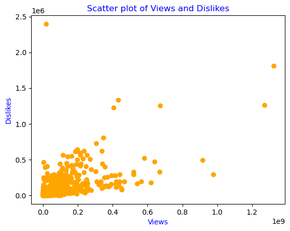

```python
#plot the scatter plot for the variables 'view_count' and 'dislike'
import matplotlib.pyplot as  plt
x=df["view_count"]
y=df["dislikes"]
plt.scatter(x,y,c="orange")
plt.title("Scatter plot of Views and Dislikes",c="blue")
plt.xlabel("Views",c="blue")
plt.ylabel("Dislikes",c="blue")
plt.show()
```

Inference: The analysis indicates a positive correlation between the number of views and dislikes on YouTube videos, implying that as views increase, dislikes tend to rise as well. The scatter plot illustrates a non-linear relationship, suggesting diminishing returns for dislikes; the dislikes increase more slowly than views. Notably, a few outliers exist, signifying videos with unexpectedly high dislikes, possibly due to controversy or coordinated disliking. These outliers suggest that factors beyond views alone influence the extent of dislikes on YouTube videos.

# 14). Display all the information about the videos that were published in January, and mention the count of videos that were published in January.

```python
# videos published in January
jan_videos=df[df['published_month']=='Jan']
print("the videos published in the month of January are:")
jan_videos
```

```
the videos published in the month of January are:
```

|  | video_id | title | channel_id | channel_title | published_at | view_count | likes | dislikes | comment_count | tags | description | published_month |
| --- | --- | --- | --- | --- | --- | --- | --- | --- | --- | --- | --- | --- |
| 27 | -2Gwm7QfBnE | Q&A With Naisha | UCYwNMbogQFzMccPSuy-pPWg | MianTwins | 2021-01-21 00:05:47 | 872372 | 38626 | 239 | 621 |  | Hey Guys!!! this has been the most requested v... | Jan |
| 48 | -4sfXSHSxzA | SURPRISING BRENT WITH HIS TIKTOK CRUSH!! | UCPpATKqmMV-CNRNWYaDUwiA | Alexa Rivera | 2021-01-16 21:40:04 | 6504784 | 262477 | 5779 | 7907 |  | He had no idea! Thank you guys so much for wat... | Jan |
| 95 | -AJD1Fc5rpQ | WE ARE HAVING A BABY! \| finding out i'm pregna... | UCVsTboAhpnuL6j-tDePvNwQ | Tess Christine | 2021-01-03 21:53:48 | 533084 | 38965 | 119 | 1650 |  | I am so happy to tell you that I am pregnant!!... | Jan |
| 103 | -AuJiwjsmWk | Do Ugly Foods Taste Worse? Taste Test | UCzpCc5n9hqiVC7HhPwcIKEg | Good Mythical MORE | 2021-01-19 11:00:01 | 1057077 | 22526 | 531 | 773 | gmm good mythical morning rhettandlink rhett a... | Today, we're doing a blind taste test to deter... | Jan |
| 182 | -JhqO2KWr5U | Schlatt gets fit | UCWZp4y1jqBuvLtiyxSs_ZBw | Big guy | 2021-01-24 22:50:57 | 1724965 | 119431 | 325 | 1578 | jschlatt big guy jschlatt highlights schlatt j... | #jschlatt #schlatt #bigguy #short | Jan |
| ... | ... | ... | ... | ... | ... | ... | ... | ... | ... | ... | ... | ... |
| 37300 | zmzFL5bG-jc | DEVINE MON PERSONNAGE AVANT AKINATOR ! (c'est ... | UCIlr3byh6wmXgcPx_Tm9Ocw | Piwerre | 2021-01-16 16:12:19 | 670357 | 54462 | 832 | 1249 | Piwerre frere de michou crouton among us devin... | Discord Piwerre : https://discord.gg/QBduPgAA... | Jan |
| 37329 | zpzjex7qwrA | Lampard Sacked Within Days Rorys Misery \| Chel... | UCkD-ZOixI0a9FjIExDsHsbg | The Kick Off | 2021-01-03 20:13:49 | 428646 | 12060 | 296 | 1505 | Premier league Chelsea chelsea 1-3 Man City Ch... | The Kick Off watched Manchester City destroy C... | Jan |
| 37345 | zqyv-B6mnBM | Lil Wayne - Ain't Got Time (Audio) | UCO9zJy7HWrIS3ojB4Lr7Yqw | Lil Wayne | 2021-01-21 05:00:10 | 2238244 | 58925 | 2365 | 5539 | lil wayne weezy weezy wednesday wayne carter y... | Official audio for Lil Wayne "Ain't Got Time",... | Jan |
| 37383 | zwfu1-24T7Q | PRADA Cup Day 1 \| Full Race Replay \| PRADA Cup... | UCo15ZYO_XDRU9LI30OPtxAg | America's Cup | 2021-01-15 04:07:55 | 317382 | 2008 | 83 | 192 | America's Cup Americas Cup AC36 AC75 Presented... | The opening day of the PRADA Cup in Auckland, ... | Jan |
| 37418 | zziBybeSAtw | PELICANS at LAKERS \| FULL GAME HIGHLIGHTS \| Ja... | UCWJ2lWNubArHWmf3FIHbfcQ | NBA | 2021-01-16 05:39:05 | 2841917 | 20759 | 1049 | 2624 | NBA G League Basketball game-0022000187 Lakers... | PELICANS at LAKERS \| FULL GAME HIGHLIGHTS \| Ja... | Jan |

2108 rows × 12 columns

```python
#count of videos that were published in January using count function which returns the number of times an object appears
print("number of videos published in January:")
jan_videos.count()
```

```
number of videos published in January:
```

```
video_id           2108
title              2108
channel_id         2108
channel_title      2108
published_at       2108
view_count         2108
likes              2108
dislikes           2108
comment_count      2108
tags               2108
description        2108
published_month    2108
dtype: int64
```

```python
# information of jan_videos
jan_videos.info()
```

```
<class 'pandas.core.frame.DataFrame'>
Int64Index: 2108 entries, 27 to 37418
Data columns (total 12 columns):
 #   Column           Non-Null Count  Dtype
---  ------           --------------  -----
 0   video_id         2108 non-null   object
 1   title            2108 non-null   object
 2   channel_id       2108 non-null   object
 3   channel_title    2108 non-null   object
 4   published_at     2108 non-null   datetime64[ns]
 5   view_count       2108 non-null   int64
 6   likes            2108 non-null   int64
 7   dislikes         2108 non-null   int64
 8   comment_count    2108 non-null   int64
 9   tags             2108 non-null   object
 10  description      2108 non-null   object
 11  published_month  2108 non-null   object
dtypes: datetime64[ns](1), int64(4), object(7)
memory usage: 214.1+ KB
```